```python
import pandas as pd
import numpy as np
import re
import matplotlib.pyplot as plt
import seaborn as sns
from scipy import stats as st
from scipy.stats import binom, poisson, norm
from math import sqrt, factorial
```

**Описание проекта

Вы работаете в интернет-магазине «Стримчик», который продаёт по всему миру компьютерные игры. Из открытых источников доступны исторические данные о продажах игр, оценки пользователей и экспертов, жанры и платформы (например, Xbox или PlayStation). Вам нужно выявить определяющие успешность игры закономерности. Это позволит сделать ставку на потенциально популярный продукт и спланировать рекламные кампании. Перед вами данные до 2016 года. Представим, что сейчас декабрь 2016 г., и вы планируете кампанию на 2017-й. Нужно отработать принцип работы с данными. Неважно, прогнозируете ли вы продажи на 2017 год по данным 2016-го или же 2027-й — по данным 2026 года. В наборе данных попадается аббревиатура ESRB (Entertainment Software Rating Board) — это ассоциация, определяющая возрастной рейтинг компьютерных игр. ESRB оценивает игровой контент и присваивает ему подходящую возрастную категорию, например, «Для взрослых», «Для детей младшего возраста» или «Для подростков».

# Импорт и чтение данных

```python
df = pd.read_csv('/datasets/games.csv')
```

```python
df.info()
```

```
<class 'pandas.core.frame.DataFrame'>
RangeIndex: 16715 entries, 0 to 16714
Data columns (total 11 columns):
 #   Column           Non-Null Count  Dtype
---  ------           --------------  -----
 0   Name             16713 non-null  object
 1   Platform         16715 non-null  object
 2   Year_of_Release  16446 non-null  float64
 3   Genre            16713 non-null  object
 4   NA_sales         16715 non-null  float64
 5   EU_sales         16715 non-null  float64
 6   JP_sales         16715 non-null  float64
 7   Other_sales      16715 non-null  float64
 8   Critic_Score     8137 non-null   float64
 9   User_Score       10014 non-null  object
 10  Rating           9949 non-null   object
dtypes: float64(6), object(5)
memory usage: 1.4+ MB
```

Во фрейме 11 столбцов, 16715 строк, типы данных - строки и дробные числа.

```
Name — название
Platform — игровая платформа
Year_of_Release — год выпуска
Genre — жанр игры
NA_sales — продажи в Северной Америке (миллионы проданных копий)
EU_sales — продажи в Европе (миллионы проданных копий)
JP_sales — продажи в Японии (миллионы проданных копий)
Other_sales — продажи в других странах (миллионы проданных копий)
Critic_Score — оценка критиков (максимум 100)
User_Score — оценка пользователей (максимум 10)
Rating — рейтинг от организации ESRB.

В дальнейшем нужна проверка и приведение данных.
```

Промежуточные выводы:

Из файла 'games.csv', был создан фрейм df, в котором есть пропуски, некорректные названия столбцов и типы данных.

# Подготовка данных

## Замена названий столбцов (приведение к нижнему регистру)

```python
df.columns = df.columns.str.lower()
```

## Проверка на пропуски и ошибки

```python
# поиск явных дубликатов
print('Количество явных дубликатов:', df.duplicated().sum())
```

```
Количество явных дубликатов: 0
```

```python
# поиск пропусков в данных
df.isna().sum().sort_values(ascending=False)
```

```
critic_score       8578
rating             6766
user_score         6701
year_of_release     269
name                  2
genre                 2
platform              0
na_sales              0
eu_sales              0
jp_sales              0
other_sales           0
dtype: int64
```

```python
# ищем подробности
df[df['name'].isna()]
```

|  | name | platform | year_of_release | genre | na_sales | eu_sales | jp_sales | other_sales | critic_score | user_score | rating |
| --- | --- | --- | --- | --- | --- | --- | --- | --- | --- | --- | --- |
| 659 | NaN | GEN | 1993.0 | NaN | 1.78 | 0.53 | 0.00 | 0.08 | NaN | NaN | NaN |
| 14244 | NaN | GEN | 1993.0 | NaN | 0.00 | 0.00 | 0.03 | 0.00 | NaN | NaN | NaN |

- так как по этим играм нет никаких существенных данных, кроме продаж, то их нужно будет удалить

```python
df = df.dropna(subset = ['name'])
```

```python
# посмотрим на годы выпуска игр
df[df['year_of_release'].isna()]
```

|  | name | platform | year_of_release | genre | na_sales | eu_sales | jp_sales | other_sales | critic_score | user_score | rating |
| --- | --- | --- | --- | --- | --- | --- | --- | --- | --- | --- | --- |
| 183 | Madden NFL 2004 | PS2 | NaN | Sports | 4.26 | 0.26 | 0.01 | 0.71 | 94.0 | 8.5 | E |
| 377 | FIFA Soccer 2004 | PS2 | NaN | Sports | 0.59 | 2.36 | 0.04 | 0.51 | 84.0 | 6.4 | E |
| 456 | LEGO Batman: The Videogame | Wii | NaN | Action | 1.80 | 0.97 | 0.00 | 0.29 | 74.0 | 7.9 | E10+ |
| 475 | wwe Smackdown vs. Raw 2006 | PS2 | NaN | Fighting | 1.57 | 1.02 | 0.00 | 0.41 | NaN | NaN | NaN |
| 609 | Space Invaders | 2600 | NaN | Shooter | 2.36 | 0.14 | 0.00 | 0.03 | NaN | NaN | NaN |
| ... | ... | ... | ... | ... | ... | ... | ... | ... | ... | ... | ... |
| 16373 | PDC World Championship Darts 2008 | PSP | NaN | Sports | 0.01 | 0.00 | 0.00 | 0.00 | 43.0 | tbd | E10+ |
| 16405 | Freaky Flyers | GC | NaN | Racing | 0.01 | 0.00 | 0.00 | 0.00 | 69.0 | 6.5 | T |
| 16448 | Inversion | PC | NaN | Shooter | 0.01 | 0.00 | 0.00 | 0.00 | 59.0 | 6.7 | M |
| 16458 | Hakuouki: Shinsengumi Kitan | PS3 | NaN | Adventure | 0.01 | 0.00 | 0.00 | 0.00 | NaN | NaN | NaN |
| 16522 | Virtua Quest | GC | NaN | Role-Playing | 0.01 | 0.00 | 0.00 | 0.00 | 55.0 | 5.5 | T |

269 rows × 11 columns

- для некоторых игр год выхода можно определить по цифрам в названии игры

```python
# ищем год выхода в названии
def search_year (name_string, fmt='%Y'):
    search_year = re.findall("(?<!\d)\d{4}(?!\d)", str(name_string))
    if len(search_year):
      # обычно релиз игры делается раньше на год, чем написано в его названии, как у Madden NFL 2004
      year = int(search_year[-1]) - 1
      return year

df['year_of_release'] = df['year_of_release'].fillna(df['name'].apply(search_year))
```

- для 17 игр удалось заполнить пропуски в годе выхода

```python
# посмотрим на оценки игроков
df['user_score']
```

```
0          8
1        NaN
2        8.3
3          8
4        NaN
        ...
16710    NaN
16711    NaN
16712    NaN
16713    NaN
16714    NaN
Name: user_score, Length: 16713, dtype: object
```

```python
# есть пропуски, и что тоже странно, оценки есть и в виде целых, и в виде десятичных значений, надо посмотреть поподробнее
df['user_score'].unique()
```

```
array(['8', nan, '8.3', '8.5', '6.6', '8.4', '8.6', '7.7', '6.3', '7.4',
       '8.2', '9', '7.9', '8.1', '8.7', '7.1', '3.4', '5.3', '4.8', '3.2',
       '8.9', '6.4', '7.8', '7.5', '2.6', '7.2', '9.2', '7', '7.3', '4.3',
       '7.6', '5.7', '5', '9.1', '6.5', 'tbd', '8.8', '6.9', '9.4', '6.8',
       '6.1', '6.7', '5.4', '4', '4.9', '4.5', '9.3', '6.2', '4.2', '6',
       '3.7', '4.1', '5.8', '5.6', '5.5', '4.4', '4.6', '5.9', '3.9',
       '3.1', '2.9', '5.2', '3.3', '4.7', '5.1', '3.5', '2.5', '1.9', '3',
       '2.7', '2.2', '2', '9.5', '2.1', '3.6', '2.8', '1.8', '3.8', '0',
       '1.6', '9.6', '2.4', '1.7', '1.1', '0.3', '1.5', '0.7', '1.2',
       '2.3', '0.5', '1.3', '0.2', '0.6', '1.4', '0.9', '1', '9.7'],
      dtype=object)
```

Так как в указанных выше 4 столбцах большое количество пропусков, а пропуски в рейтинге нельзя заполнить просто нулями, надо будет поставить маркер, например, "-0.1", что явно вне предела рейтинга и этот маркер в дальнейшем отсеивать.

Аббревиатура "tbd" в df['user_score'] буквально означает to be determined, и, судя по тому, что продажи этих игр не проводились в некоторых регионах, то для них издатель либо не стремился получать оценку, либо оценка не могла быть представлена, т.к. не было объективности в представлении нишевых игр - по платформе или региону.

```python
# закрытие NaN-ов маркерами
df['year_of_release'] = df['year_of_release'].fillna(-0.1)
df['critic_score'] = df['critic_score'].fillna(-0.1)

df['user_score'] = df['user_score'].replace('tbd', np.NAN)
df['user_score'] = df['user_score'].fillna(-0.1)
```

```python
# посмотрим на рейтинг
df['rating'].unique()
```

```
array(['E', nan, 'M', 'T', 'E10+', 'K-A', 'AO', 'EC', 'RP'], dtype=object)
```

- так как это категории, а не цифры, то забить их медианой или средним не получится, тоже поставим маркер 'undef'(ined)

```python
df['rating'] = df['rating'].fillna('undef')
```

```python
# повторный поиск пропусков в данных
df.isna().sum().sort_values()
```

```
name               0
platform           0
year_of_release    0
genre              0
na_sales           0
eu_sales           0
jp_sales           0
other_sales        0
critic_score       0
user_score         0
rating             0
dtype: int64
```

## Преобразование данных в нужные типы

```python
# приведение строк в цифры
df['year_of_release'] = df['year_of_release'].astype(int)
```

```python
# перевод в числа с точкой
df['user_score'] = df['user_score'].astype('float')
```

```python
# т.к. у нас 10- и 100-балльные системы оценки, надо их привести к единому знаменателю
df['user_score'] = df['user_score'] * 10
```

```python
# V1
# Посчитаем суммарные продажи во всех регионах и запишем их в отдельный столбец
#df['total_sales'] = df['na_sales'] + df['eu_sales'] + df['jp_sales'] + df['other_sales']
df['total_sales'] = df[['na_sales','eu_sales','jp_sales','other_sales']].sum(axis=1)
# работает, однако...
```

```python
# промежуточные результаты
print(df.info())
display(df.sample(15))
```

```
<class 'pandas.core.frame.DataFrame'>
Int64Index: 16713 entries, 0 to 16714
Data columns (total 12 columns):
 #   Column           Non-Null Count  Dtype
---  ------           --------------  -----
 0   name             16713 non-null  object
 1   platform         16713 non-null  object
 2   year_of_release  16713 non-null  int64
 3   genre            16713 non-null  object
 4   na_sales         16713 non-null  float64
 5   eu_sales         16713 non-null  float64
 6   jp_sales         16713 non-null  float64
 7   other_sales      16713 non-null  float64
 8   critic_score     16713 non-null  float64
 9   user_score       16713 non-null  float64
 10  rating           16713 non-null  object
 11  total_sales      16713 non-null  float64
dtypes: float64(7), int64(1), object(4)
memory usage: 1.7+ MB
None
```

|  | name | platform | year_of_release | genre | na_sales | eu_sales | jp_sales | other_sales | critic_score | user_score | rating | total_sales |
| --- | --- | --- | --- | --- | --- | --- | --- | --- | --- | --- | --- | --- |
| 8715 | Major League Baseball 2K13 | PS3 | 2013 | Sports | 0.14 | 0.00 | 0.00 | 0.02 | -0.1 | -1.0 | undef | 0.16 |
| 6000 | Jeremy McGrath Supercross 2000 | N64 | 1999 | Racing | 0.23 | 0.06 | 0.00 | 0.00 | -0.1 | -1.0 | undef | 0.29 |
| 3054 | 100 Classic Books | DS | 2008 | Misc | 0.12 | 0.52 | 0.00 | 0.02 | 70.0 | 60.0 | undef | 0.66 |
| 5252 | Trauma Center: Under the Knife | DS | 2005 | Simulation | 0.30 | 0.01 | 0.02 | 0.03 | 81.0 | 87.0 | T | 0.36 |
| 14520 | BeatMania IIDX 13: DistorteD | PS2 | 2007 | Simulation | 0.00 | 0.00 | 0.03 | 0.00 | -0.1 | -1.0 | undef | 0.03 |
| 3608 | TMNT | X360 | 2007 | Action | 0.48 | 0.03 | 0.00 | 0.05 | 58.0 | 63.0 | E10+ | 0.56 |
| 12907 | BlowOut | XB | 2003 | Shooter | 0.04 | 0.01 | 0.00 | 0.00 | 55.0 | -1.0 | T | 0.05 |
| 3602 | Major League Baseball 2K5 | XB | 2005 | Sports | 0.52 | 0.02 | 0.00 | 0.02 | 81.0 | 82.0 | E | 0.56 |
| 586 | Medal of Honor | X360 | 2010 | Shooter | 1.56 | 0.80 | 0.04 | 0.21 | 74.0 | 67.0 | M | 2.61 |
| 16427 | Element Hunter | DS | 2009 | Role-Playing | 0.00 | 0.00 | 0.01 | 0.00 | -0.1 | -1.0 | undef | 0.01 |
| 6872 | Dance Dance Revolution: Disney Channel Edition | PS2 | 2008 | Simulation | 0.12 | 0.09 | 0.00 | 0.03 | 61.0 | -1.0 | E | 0.24 |
| 8204 | Transformers: Prime | 3DS | 2012 | Action | 0.13 | 0.02 | 0.00 | 0.02 | -0.1 | -1.0 | undef | 0.17 |
| 7079 | I Love Horses | DS | 2008 | Simulation | 0.21 | 0.00 | 0.00 | 0.01 | -0.1 | -1.0 | E | 0.22 |
| 16139 | Coronation Street: The Mystery of the Missing ... | PC | 2011 | Adventure | 0.00 | 0.01 | 0.00 | 0.00 | -0.1 | -1.0 | undef | 0.01 |
| 6168 | Guitar Hero: Van Halen | Wii | 2009 | Misc | 0.13 | 0.12 | 0.00 | 0.03 | 50.0 | 52.0 | T | 0.28 |

Промежуточные выводы:

- в преобразовании нуждались следующие столбцы: year_of_release нужно было перевести из float в int, user_score из object в float, т.к. это строка, но значения в ней выражают числа с запятой
- пропуски в таблице могли возникнуть как по причине заполнения или переноса данных от аггрегатора, так и по причине того, что на момент выхода игры необходимого метода оценки не существовало (или даже организации, которая его проводила).
- аббревиатура "tbd" в df['user_score'] буквально означает to be determined, и, судя по тому, что продажи этих игр не проводились в некоторых регионах, то для них издатель либо не стремился получать оценку, либо оценка не могла быть представлена, т.к. не было объективности в представлении нишевых игр - по платформе или региону.
- для общих продаж по всему миру сделан отдельный столбец df['total_sales'], в который просуммированы продажи игры по всем регионам
- две "пустые" строки были удалены

# Исследовательский анализ данных

## Анализ выхода игр по годам

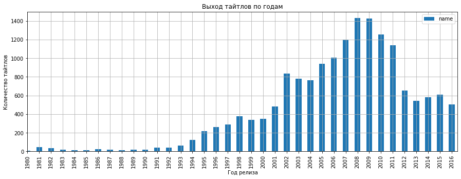

```python
# V1
# построим гистограмму с отображением количества игр по годам
year_present = df.pivot_table(index = 'year_of_release', values = 'name', aggfunc = 'count')
year_present.plot( kind='bar', figsize = (15,5), grid = True )
plt.xlim(1,)
plt.title('Выход тайтлов по годам')
plt.xlabel('Год релиза')
plt.ylabel('Количество тайтлов')
plt.show()
```

Условно историю продаж надо отслеживать с 1994 года, т.к. это год, когда количество выпускаемых игр превысило предыдущий в два раза, т.е. отрасль начинает расти взрывными темпами, и тогда же для регуляции и создали ассоциацию ESRB. Своего пика рынок достиг в 2008 году, после которого началось заметное и неуклонное падение. Тут свою роль сыграл мировой финансовый кризис, общее удорожание и усложнение производства, а также постепенный переток на мобильные платформы, когда телефоны и планщеты уже стали достаточно мощными, а экраны для них подешевели при том же графическом качестве.

- сместил шкалу к 1980, без заглушки

## Анализ продаж по платформам

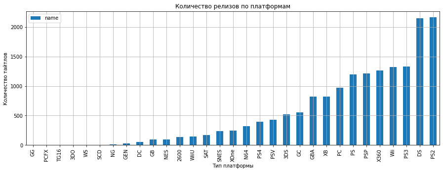

```python
# сперва надо определить лидеров по продажам
plat_numbers = df.pivot_table(index = 'platform', values = 'name', aggfunc = 'count').sort_values('name')
plat_numbers.plot( kind='bar', figsize = (15,5), grid = True)
plt.title('Количество релизов по платформам')
plt.xlabel('Тип платформы')
plt.ylabel('Количество тайтлов')
plt.show()
```

Лидеры - PS2, DS, PS3, Wii, X360, два кита индустрии - Сони и Нинтендо, и небольшая доля Майкрософт.

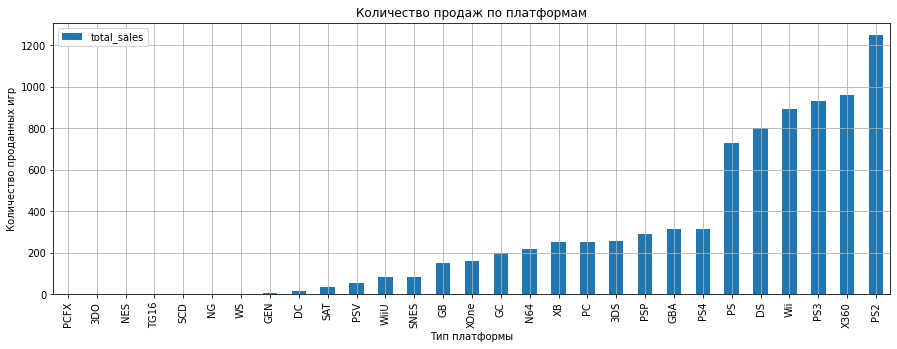

```python
plat_sales=df[df['year_of_release'] >= 1994].pivot_table(index = 'platform',values ='total_sales',
                                                         aggfunc = 'sum').sort_values('total_sales')
plat_sales.plot( kind='bar', figsize = (15,5), grid = True)
plt.title('Количество продаж по платформам')
plt.xlabel('Тип платформы')
plt.ylabel('Количество проданных игр')
plt.show()
```

По количеству продаж - те же фигуранты, но Майкрософт по продажам вырвался вперёд, с 5 места на 2. Возможно, свою роль сыграло количество поддерживаемых старых игр или очень удачная политика, позволяющая выпускать большое количество хитов.

```python
# создадим список топ-5 по продажам, т.к. график по восходящей, то данные берём из последних значений
plat_top = plat_sales.tail(5).index.tolist()
# сводная таблица топ-5 по продажам в зависимости от года
plat_top_sales = df[(df['platform'].isin(plat_top)) & (df['year_of_release'] >= 1994)].pivot_table(
    index = ['platform','year_of_release'], values = 'total_sales', aggfunc = 'sum').reset_index()
```

```python
# сводная таблица топ-5 по продажам в зависимости от года
plat_top_sales = df[(df['platform'].isin(plat_top)) & (df['year_of_release'] >= 1994)].pivot_table(
    index = ['platform','year_of_release'], values = 'total_sales', aggfunc = 'sum').reset_index()
```

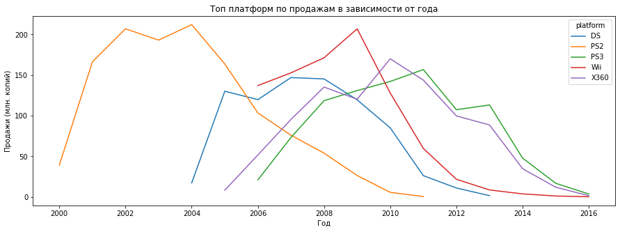

```python
# график продаж в зависимости от года для каждой платформы
plt.figure(figsize=(15,5))
ax = sns.lineplot(x = 'year_of_release', y = 'total_sales', data = plat_top_sales, hue = 'platform')
ax.set(xlabel = 'Год', ylabel = 'Продажи (млн. копий)', title = 'Топ платформ по продажам в зависимости от года')
plt.show()
```

Эмпирически известно, что среднее время существования поколения игровой платформы, или даже можно сказать - экосистемы, составляет 10 лет, за которые она успевает окончательно и безвозвратно устареть морально и технически, а графики лишь детально отображают эти данные. Условный же пик продаж приходится примерно на 4-й год после запуска.

## Какие платформы лидируют по продажам, растут или падают?

Так как мы определили среднюю продолжительность жизни игровой системы в 10 лет, то для 2016 года нужно выбрать период изучения с 2006 года.

```python
# топ-10 актуальных на 2016 год платформ
living_platforms = df[(df['year_of_release'] >= 2016)].pivot_table(index = ['platform'],
    values = 'total_sales', aggfunc = 'sum').sort_values('total_sales', ascending=False).head(10).index.tolist()
#
platform_perspective = df[(df['platform'].isin(living_platforms)) & (df['year_of_release'] >= 2006)].pivot_table(
    index = ['platform','year_of_release'], values = 'total_sales', aggfunc = 'sum').reset_index()
```

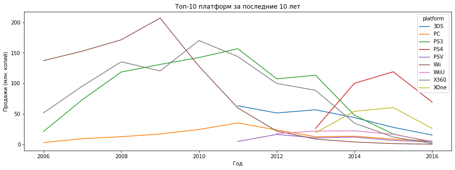

```python
plt.figure(figsize=(15,5))
ax = sns.lineplot(x = 'year_of_release', y = 'total_sales', data = platform_perspective, hue = 'platform')
ax.set(xlabel = 'Год', ylabel = 'Продажи (млн. копий)', title = 'Топ-10 платформ за последние 10 лет')
plt.show()
```

Как видно из графиков, переломным периодом стал год кризиса - 2008, когда финансовые проблемы банков по нисходящей дошли за 2-3 года до всех участников игрового рынка - от производителей и издателей до игроков. 2014 год окончательно добил классические игровые системы, когда даже свежая Sony PS4 достигла пика всего за 2 года и дальше начала драматически падать. Лаг в 2-3 года условно отображает длительность разработки и наличие денежных средств ещё на старых условиях.

## Выберите несколько потенциально прибыльных платформ

```python
# уточнённый график с момента последнего перелома, т.е. 2014 года
platform_perspect = df[(df['platform'].isin(living_platforms)) & (df['year_of_release'] >= 2014)].pivot_table(
    index = ['platform','year_of_release'], values = 'total_sales', aggfunc = 'sum').reset_index()
```

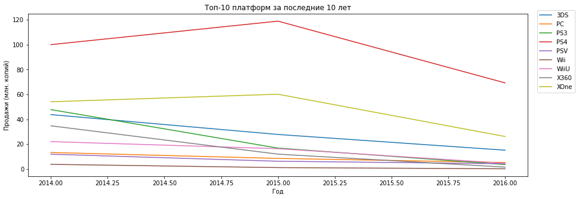

```python
plt.figure(figsize=(15,5))
ax = sns.lineplot(x = 'year_of_release', y = 'total_sales', data = platform_perspect, hue = 'platform')
ax.set(xlabel = 'Год', ylabel = 'Продажи (млн. копий)', title = 'Топ-10 платформ за последние 10 лет')
ax.legend(loc='right', bbox_to_anchor=(1.1, 0.77), ncol=1)
plt.show()
```

Как видно из уточнённых графиков, все платформы неуклонно движутся к закату, троица самых продаваемых систем: Sony PS4, MS XBox One, Nintendo 3DS. Сказать об их прибыльности нельзя, т.к. неизвестны затраты на разработку, издание и дистрибуцию.

## Постройте график «ящик с усами» по глобальным продажам игр в разбивке по платформам

```python
# выборка по годам после 2014 и платформам
actual_platform = df[(df['platform'].isin(living_platforms)) & (df['year_of_release'] >= 2014)]
```

```python
#V1
# из выборки отсеем пятёрку лидеров
display(actual_platform.groupby('platform')['total_sales'].sum().sort_values(ascending=False).head(5))
```

```
platform
PS4     288.15
XOne    140.36
3DS      86.68
PS3      68.18
X360     48.22
Name: total_sales, dtype: float64
```

```python
#V1
# теперь оставим в выборке только лидеров из топ-5
top_5 = actual_platform.query("platform == ('PS4','XOne','3DS','PS3','X360')")
```

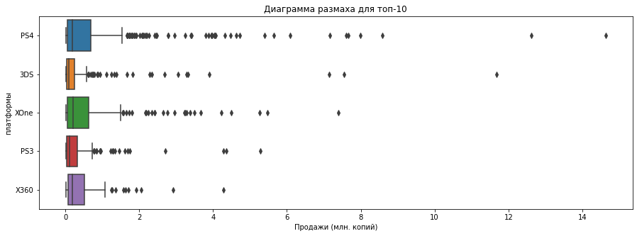

```python
plt.figure(figsize=(15,5))
ax = sns.boxplot(x = top_5['total_sales'], y = top_5['platform'])
ax.set(xlabel = 'Продажи (млн. копий)', ylabel = 'платформы', title = 'Диаграмма размаха для топ-10')
plt.show()
```

Выбросы за пределами нормали говорят о наличии единичных хитов, которые искажают картину. Предел Сони находится на уровне чуть более 1.5 млн, поэтому имеет смысл построить уточнёную диаграмму в этих пределах.

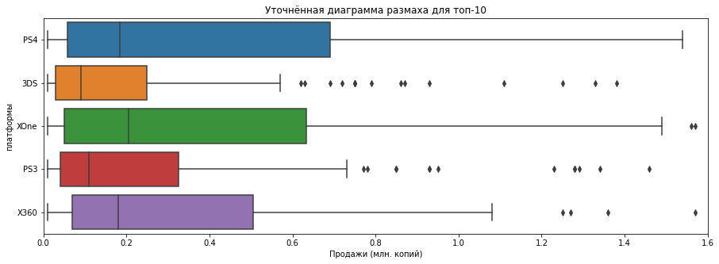

```python
plt.figure(figsize=(15,5))
ax = sns.boxplot(x = top_5['total_sales'], y = top_5['platform'])
ax.set(xlabel = 'Продажи (млн. копий)', ylabel = 'платформы', xlim = [0,1.6], title = 'Уточнённая диаграмма размаха для топ-10')
plt.show()
```

Если рассмотреть троицу: PS4, XBox One, Xbox 360, то можно прийти к выводу, что самой стабильной в плане продаж является Xbox (и её же брат Xbox 360), а PS4 и PS3 чаще делают ставку на хиты и попытки завоевания новых ниш или жанров, при этом Сони в этом плане рискует чаще и сильнее, да и PS3 давно устарела, поэтому её продажи надо учитывать в уменьшающейся перспективе. DS3 же здесь выглядит исключительно нишевым продуктом, выплывающим из-за армии фанатов или узкого круга специфичных игр, которые больше никто не делает, несмотря на третье место по продажам. Но, наблюдая общую картину, надо также держать в голове, что многие игры являются кроссплатформенными, и поэтому одна игра может попадать сразу в несколько графов (платформ).

## Постройте диаграмму рассеяния и посчитайте корреляцию между отзывами и продажами

Как мы видели выше, лидером с 2014 года по продажам является PS4, поэтому её и возьмём в качестве бенчмарка. На диграмме отобразим разброс мнений, где краcными будут мнения критиков, а синими - мнения игроков.

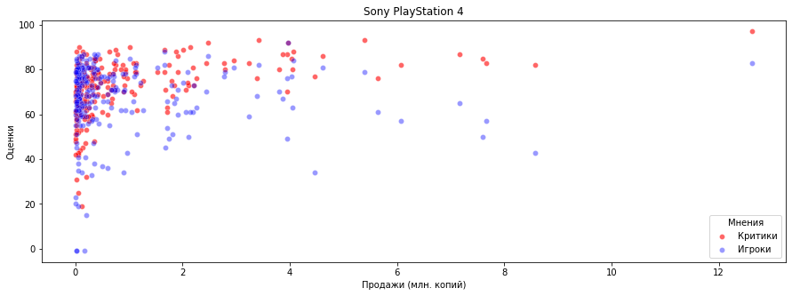

```
Корреляция продаж и оценки критиков для платформы Sony PlayStation 4: 0.403
Корреляция продаж и оценки пользователей для платформы Sony PlayStation 4: -0.009
```

```python
# V1
benchmark_ps4 = top_5[(top_5['platform'] == 'PS4') & (top_5['critic_score'] >= 0)]
plt.figure(figsize=(15,5))
ax = sns.scatterplot(x='total_sales', y='critic_score', data = benchmark_ps4, alpha = 0.6, color='red')
ax = sns.scatterplot(x='total_sales', y='user_score', data = benchmark_ps4, alpha = 0.4, color='blue');
ax.set(xlabel = 'Продажи (млн. копий)', ylabel = 'Оценки', title = 'Sony PlayStation 4')
plt.legend(title='Мнения', loc='lower right', labels=['Критики', 'Игроки'])
plt.show()
print(f'Корреляция продаж и оценки критиков для платформы Sony PlayStation 4:',
    round(benchmark_ps4['total_sales'].corr(benchmark_ps4['critic_score']),3))
print(f'Корреляция продаж и оценки пользователей для платформы Sony PlayStation 4:',
    round(benchmark_ps4['total_sales'].corr(benchmark_ps4['user_score']),3))
```

Как видно из значения корелляции, критики чаще ставят положительные оценки, а на графике это выражается в том, что после преодоления игрой планки продаж в 2 млн их оценки уже никогда не падают ниже 60 баллов. Корелляция мнений игроков ниже, и они чаще ставят низкие оценки. Тут может быть как отсутствие влияния корпораций (методы воздействия последних на игрожур давно и широко известны), так и то, что игроки могут ставить оценки под влиянием эмоций, соцсетей и "просто потому что могу".

## Соотнесение выводов с продажами игр на других платформах

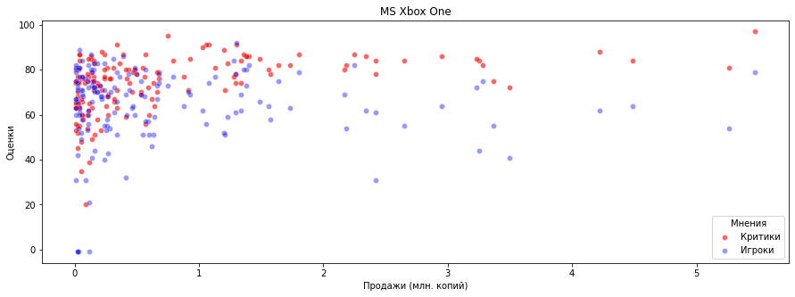

```
Корреляция продаж и оценки критиков для платформы MS Xbox One: 0.429
Корреляция продаж и оценки пользователей для платформы MS Xbox One: -0.001
```

```python
benchmark_xone = top_5[(top_5['platform'] == 'XOne') & (top_5['critic_score'] >= 0)]
plt.figure(figsize=(15,5))
ax = sns.scatterplot(x='total_sales', y='critic_score', data = benchmark_xone, alpha = 0.6, color='red',)
ax = sns.scatterplot(x='total_sales', y='user_score', data = benchmark_xone, alpha = 0.4, color='blue');
ax.set(xlabel = 'Продажи (млн. копий)', ylabel = 'Оценки', title = 'MS Xbox One')
plt.legend(title='Мнения', loc='lower right', labels=['Критики', 'Игроки'])
plt.show()
print(f'Корреляция продаж и оценки критиков для платформы MS Xbox One:',
    round(benchmark_xone['total_sales'].corr(benchmark_xone['critic_score']),3))
print(f'Корреляция продаж и оценки пользователей для платформы MS Xbox One:',
    round(benchmark_xone['total_sales'].corr(benchmark_xone['user_score']),3))
```

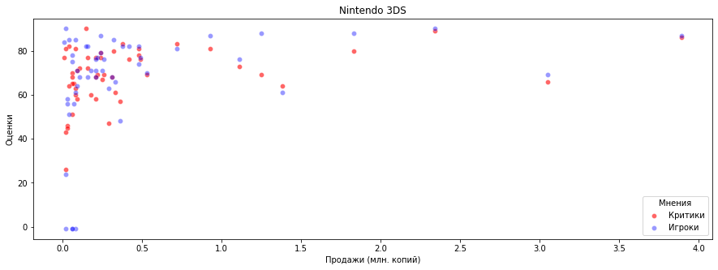

```
Корреляция продаж и оценки критиков для платформы Nintendo 3DS: 0.314
Корреляция продаж и оценки пользователей для платформы Nintendo 3DS: 0.282
```

```python
benchmark_3ds = top_5[(top_5['platform'] == '3DS') & (top_5['critic_score'] >= 0)]
plt.figure(figsize=(15,5))
ax = sns.scatterplot(x='total_sales', y='critic_score', data = benchmark_3ds, alpha = 0.6, color='red',)
ax = sns.scatterplot(x='total_sales', y='user_score', data = benchmark_3ds, alpha = 0.4, color='blue');
ax.set(xlabel = 'Продажи (млн. копий)', ylabel = 'Оценки', title = 'Nintendo 3DS')
plt.legend(title='Мнения', loc='lower right', labels=['Критики', 'Игроки'])
plt.show()
print(f'Корреляция продаж и оценки критиков для платформы Nintendo 3DS:',
    round(benchmark_3ds['total_sales'].corr(benchmark_3ds['critic_score']),3))
print(f'Корреляция продаж и оценки пользователей для платформы Nintendo 3DS:',
    round(benchmark_3ds['total_sales'].corr(benchmark_3ds['user_score']),3))
```

## Посмотрите на общее распределение игр по жанрам. Что можно сказать о самых прибыльных жанрах? Выделяются ли жанры с высокими и низкими продажами?

Для начала надо отфильтвовать все жанры по популярности:

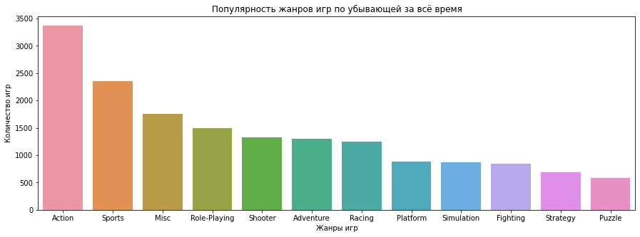

```python
genre_count = df.pivot_table(index = 'genre', values = 'name',
                                  aggfunc = 'count').sort_values('name', ascending = False)

plt.figure(figsize=(15,5))
ax = sns.barplot(x = genre_count.index, y = 'name', data = genre_count)
ax.set(xlabel = 'Жанры игр', ylabel = 'Количество игр', title = 'Популярность жанров игр по убывающей за всё время')
plt.show()
```

Как мы видим, самыми популярными являются жанры action, sports и misc(различные, не имеющие явной определённости).

Если отфильтровать по взятому выше 2014 году, картина несколько изменится:

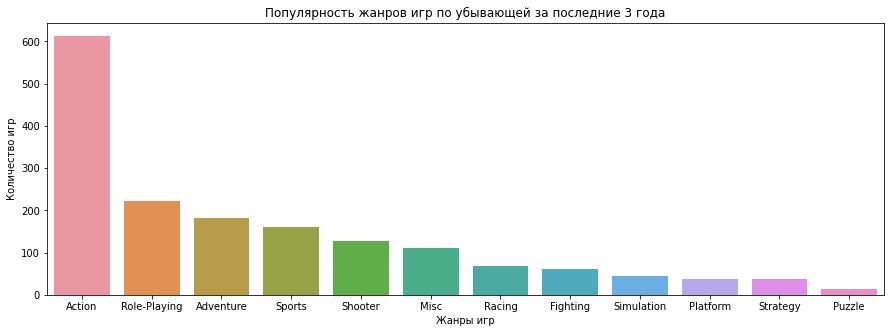

```python
actual_genre_count = actual_platform.pivot_table(index = 'genre', values = 'name',
                                                      aggfunc = 'count').sort_values('name', ascending = False)

plt.figure(figsize=(15,5))
ax = sns.barplot(x = actual_genre_count.index, y = 'name', data = actual_genre_count)
ax.set(xlabel = 'Жанры игр', ylabel = 'Количество игр', title = 'Популярность жанров игр по убывающей за последние 3 года')
plt.show()
```

Жанр action остался на троне, но жанры RPG и adventure резко прыгнули в популярности. И опять же надо помнить, что многие игры относятся к смешанным жанрам.

Жанры с высокими и низкими продажами выглядят так:

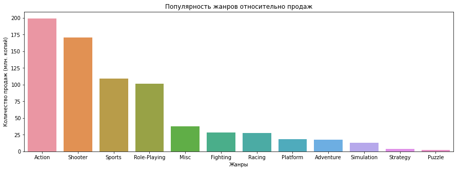

```python
actual_genre_sales = actual_platform.pivot_table(index = 'genre', values = 'total_sales',
                                                      aggfunc = 'sum').sort_values('total_sales', ascending = False)
plt.figure(figsize=(15,5))
ax = sns.barplot(x = actual_genre_sales.index, y = 'total_sales', data = actual_genre_sales)
ax.set(xlabel = 'Жанры', ylabel = 'Количество продаж (млн. копий)', title = 'Популярность жанров относительно продаж')
plt.show()
```

Жанр action и здесь на коне, но его отрыв от следующих призёров уже значительно ниже. Жанры shooter и sports идут следющими по популярности, из чего можно предположить, что эта троица является наиболее популярной у взрослой платёжеспособной мужской аудитории, т.к. мужчины оставляют 9/10 всех игроков.

Построим бокс-диаграмму для этих же критериев

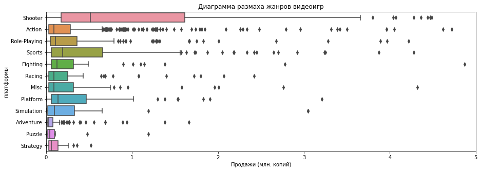

```python
plt.figure(figsize=(15,5))
ax = sns.boxplot(x = actual_platform['total_sales'], y = actual_platform['genre'])
ax.set(xlabel = 'Продажи (млн. копий)', ylabel = 'платформы', xlim = [0,5], title = 'Диаграмма размаха жанров видеоигр')
plt.show()
```

# Определение портрета пользователя для каждого региона (NA, EU, JP, O)

Создадим функцию для нарисования совместных "пироговых" графиков:

```python
def pirog (data, title):
    fig, ((ax1, ax2), (ax3, ax4)) = plt.subplots(2, 2, figsize=(9,9))
    palette = sns.color_palette('pastel')[ 0:5 ]
    fig.suptitle(title)
    ax1.pie(data['na_sales'], labels = data.index, autopct='%1.1f%%', colors = palette, normalize=True)
    ax1.set_title('Северная Америка')
    ax2.pie(data['eu_sales'], labels = data.index, autopct='%1.1f%%', colors = palette, normalize=True)
    ax2.set_title('Евросоюз')
    ax3.pie(data['jp_sales'], labels = data.index, autopct='%1.1f%%', colors = palette, normalize=True)
    ax3.set_title('Япония')
    ax4.pie(data['other_sales'], labels = data.index, autopct='%1.1f%%', colors = palette, normalize=True)
    ax4.set_title('Прочие регионы')
    fig.tight_layout()
```

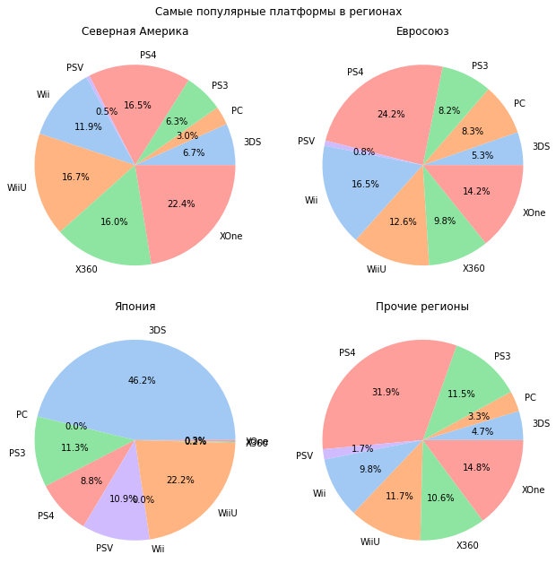

```python
# создадим выборку по платформам в регионах и передадим эти данные в функцию
platform_region_sales=actual_platform.pivot_table(index='platform',
                                                  values=['na_sales', 'eu_sales', 'jp_sales', 'other_sales'])
pirog(platform_region_sales, 'Самые популярные платформы в регионах')
```

В прочих странах, не входящих в эти регионы, ситуация больше похожа на европейскую: лидеры PS4 - 31.9%, Xbox One - 14.8%, WiiU - 11.7%.

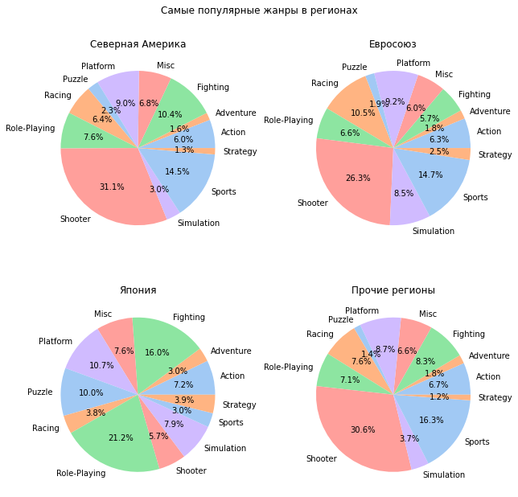

```python
#создадим выборку по жанрам
genre_region_sales=actual_platform.pivot_table(index='genre',
                                               values=['na_sales', 'eu_sales', 'jp_sales', 'other_sales'])
pirog(genre_region_sales, 'Самые популярные жанры в регионах')
```

В Америке предпочитают такие жанры, как shooter, sports, fighting. В Европе shooter, sports, racing. Во всем мире, кроме Японии, предпочтения схожие - shooter, sports, platform. Fighting не дотянул дольку процента. В Японии, как обчно, ситуация кардинально отличается - RPG, а точнее - JRPG, с классическим RPG пересекающийся очень слабо, fighting, и замыкает жанр платформеров - platform.

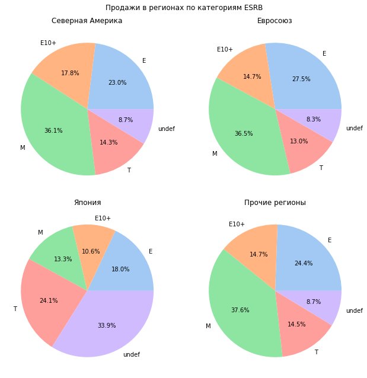

```python
rating_region_sales=actual_platform.pivot_table(index='rating',
                                                values=['na_sales', 'eu_sales', 'jp_sales', 'other_sales'])
pirog(rating_region_sales, 'Продажи в регионах по категориям ESRB')
```

## Проверка гипотезы: "Средние пользовательские рейтинги платформ Xbox One и PC одинаковые"

Нулевая гипотеза (H0): средние пользовательские рейтинги платформ Xbox One и PC одинаковые Альтернативная гипотеза (H1): средние пользовательские рейтинги платформ Xbox One и PC не одинаковые

Нулевая гипотеза взята без изменений прямо задания, поэтому альтернативная сформулирована как противоположная ей.

Создадим две выборки, которые и будем сравнивать:

```python
user_score_pc = df[(df['platform'] == 'PC') & (df['user_score'] >= 0)]['user_score']
user_score_xone = df[(df['platform'] == 'XOne') & (df['user_score'] >= 0)]['user_score']

print('Количество значений выборки для платформы PC:', user_score_pc.shape[0])
print('Количество значений выборки для платформы Xbox One:', user_score_xone.shape[0])
```

```
Количество значений выборки для платформы PC: 770
Количество значений выборки для платформы Xbox One: 182
```

```python
#уровень значимости стандартный 5%
alpha = 0.05

result = st.ttest_ind(user_score_pc, user_score_xone, equal_var = False)

print('Значение P-value ', round(result.pvalue, 5))

if result.pvalue < alpha:
    print('Гипотеза Н0 опровергнута')
else:
    print('Гипотеза Н0 не опровергнута')
```

```
Значение P-value  0.0
Гипотеза Н0 опровергнута
```

```python
# иначе говоря
print('Среднее значение оценок пользователей платформы PC:', round(user_score_pc.mean(),2))
print('Среднее значение оценок пользователей платформы Xbox One:', round(user_score_xone.mean(),2))
```

```
Среднее значение оценок пользователей платформы PC: 70.62
Среднее значение оценок пользователей платформы Xbox One: 65.21
```

Вывод: исходя из полученных значений нельзя сказать, что средние пользовательские рейтинги платформ Xbox One и PC одинаковые, поэтому в рассмотрение принимается альтернативная гипотеза Н1.

## Проверка гипотезы: "Средние пользовательские рейтинги жанров Action (англ. «действие», экшен-игры) и Sports (англ. «спортивные соревнования») разные"

Нулевая гипотеза (H0): средние пользовательские рейтинги жанров Action и Sports одинаковые Альтернативная гипотеза (H1): средние пользовательские рейтинги жанров Action и Sports не одинаковые

Нулевая гипотеза взята без изменений прямо задания, поэтому альтернативная сформулирована как противоположная ей.

Создадим две выборки, которые и будем сравнивать:

```python
user_score_аction = df[df['genre'] == 'Action']['user_score']
user_score_sports = df[df['genre'] == 'Sports']['user_score']

print('Количество значений выборки для жанра Action:', user_score_аction.shape[0])
print('Количество значений выборки для жанра Sports:', user_score_sports.shape[0])
```

```
Количество значений выборки для жанра Action: 3369
Количество значений выборки для жанра Sports: 2348
```

Чтобы проверить гипотезы, нужно применить т-тест, а так как выборки получились разного размера (с отличием примерно в 1.5 раза), и есть вероятность, что дисперсии у совокупностей разные, то параметр equal_var надо поставить в "False".

```python
alpha = 0.05

result = st.ttest_ind(user_score_аction, user_score_sports, equal_var = False)

print('Значение P-value ', round(result.pvalue, 5))

if result.pvalue < alpha:
    print('Гипотеза Н0 опровергнута')
else:
    print('Гипотеза Н0 не опровергнута')
```

```
Значение P-value  0.0
Гипотеза Н0 опровергнута
```

```python
# иначе говоря
print('Среднее значение оценок пользователей жанра Action:', round(user_score_аction.mean(),2))
print('Среднее значение оценок пользователей жанра Sports:', round(user_score_sports.mean(),2))
```

```
Среднее значение оценок пользователей жанра Action: 37.86
Среднее значение оценок пользователей жанра Sports: 32.17
```

# Общие выводы

Из файла 'games.csv' был создан рабочий фрейм df, над которым и проводились действия:

- имена столбцов приведены к нижнему регистру
- данные проверены на наличие пустот, неверных значений в ячейках, дубликатов и прочих ошибок. Строки, которые можно было удалить без ущерба для основной картины, были удалены
- год игры, там где он не был проставлен, частично удалось заполнить исходя из их названий
- убраны ошибки типа NaN и неверные значения, вроде строк вместо цифр
- данные преобразованы для лучшего управления, рейтинги приведены к единой сетке в 100 баллов

В ходе анализа данных было установлено следующее:

- точкой отсчёта по рейтингам является 1994 год
- самыми популярными являются японские производители, при очень скромной доле американского Misrosoft
- при этом Misrosoft за счёт лучшего маркетинга занимает второе место по продажам игр, несмотря на меньшее количество выпущенных приставок
- среднее время жизни игровой платформы 10 лет, с пиком популярности 4 года после выпуска
- после 2008 года все платформы падают по продажам, независимо от типа, и данная тенденция не переламывается, срок жизни платформ и их популярности резко сокращается
- о прибыльности платформ нельзя достоверно судит ьпо их продажам, но продажи так же неуклонно падают
- исходя их разброса продаж игр, Misrosoft лучше всего подстраивается под рынок и меньше подвержена перепадам, прочие производители вынужденые чаще рисковать

О влиянии рейтингов на продажи можно сказать, что:

- существует положительаня корелляция между высокими рейтингами журналистов и продажами игр, т.е. покупатели являются зависимым от чужого мнения большинством

О популярности игровых жанров можно сказать, что:

- наиболее популярными за все время наблюдения является жанр action, все прочие преодически меняются местами, но лидерства не захватывают, и этот же жанр является самым прибыльным
- из популярности жанра action можно предположить, что целевой аудиторией являются взрослые мужчины, и они же являются самой платёжеспособной категорией

О гипотезах:

- В результате проверки отвергли гипотезу о том, что средние пользовательские рейтинги платформ Xbox One и PC одинаковые
- В результате другой проверки отвергли гипотезу о том, что средние пользовательских оценок для жанров Action и Sports одинаковы